# NYPD Shooting Incident

## ANALYZING DATA

```r
nypd_csvData_Incidents <- nypd_csvData %>%
filter(year(OCCUR_DATE)==2021 & PERP_AGE_GROUP=="25-44")

nypd_csvData_Incidents_plot <- nypd_csvData_Incidents %>%
mutate(OCCUR_Month = month(OCCUR_DATE))

nypd_csvData_Incidents_plot <- nypd_csvData_Incidents_plot %>%
group_by(OCCUR_Month)%>%
summarise(Incidents = n(), Deaths = sum(STATISTICAL_MURDER_FLAG))

nypd_csvData_Incidents_plot <- nypd_csvData_Incidents_plot %>%
mutate(OCCUR_MonthName = month(OCCUR_Month,label = TRUE, abbr = TRUE))

nypd_csvData_Incidents_plot
```

```
## # A tibble: 12 × 4
##    OCCUR_Month Incidents Deaths OCCUR_MonthName
##          <dbl>     <int>  <int> <ord>
##  1           1        21      5 Jan
##  2           2        21      6 Feb
##  3           3        44     16 Mar
##  4           4        40     15 Apr
##  5           5        68     20 May
##  6           6        59     19 Jun
##  7           7        49     13 Jul
##  8           8        54     16 Aug
##  9           9        44     12 Sep
## 10          10        37     10 Oct
## 11          11        24      5 Nov
## 12          12        27     11 Dec
```

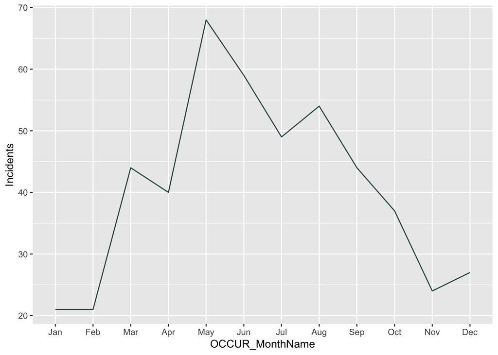

```r
nypd_csvData_Incidents_plot %>% ggplot(aes(x=OCCUR_MonthName, y=Incidents, group = 1))+geom_line(color="darkslategrey")
```

We have concluded that :

The shooting incidents tend to increase between the months March and August and tends to decrease between September and February.  
May reported the highest shootings whereas January and February reported the least.  
There is almost 69% decrease in shootings in May vs January and February.

## MODELING THE DATA

A linear regression is a statistical model that analyzes the relationship between a response variable (often called y) and one or more variables and their interactions (often called x or explanatory variables). You make this kind of relationships in your head all the time, for example when you calculate the age of a child based on her height, you are assuming the older she is, the taller she will be.

Similarly, we can assume that as the **number of incidents increases, the death rate also increases.**

```r
mod <- lm(Deaths ~ Incidents, data = nypd_csvData_Incidents_plot)

summary(mod)
```

```
##
## Call:
## lm(formula = Deaths ~ Incidents, data = nypd_csvData_Incidents_plot)
##
## Residuals:
##     Min      1Q  Median      3Q     Max
## -2.1290 -1.2377 -0.6826  1.3629  2.9342
##
## Coefficients:
##             Estimate Std. Error t value Pr(>|t|)
## (Intercept) -0.36524    1.66713  -0.219    0.831
## Incidents    0.31226    0.03854   8.101 1.05e-05 ***
## ---
## Signif. codes:  0 '***' 0.001 '**' 0.01 '*' 0.05 '.' 0.1 ' ' 1
##
## Residual standard error: 1.967 on 10 degrees of freedom
## Multiple R-squared:  0.8678, Adjusted R-squared:  0.8546
## F-statistic: 65.63 on 1 and 10 DF,  p-value: 1.054e-05
```

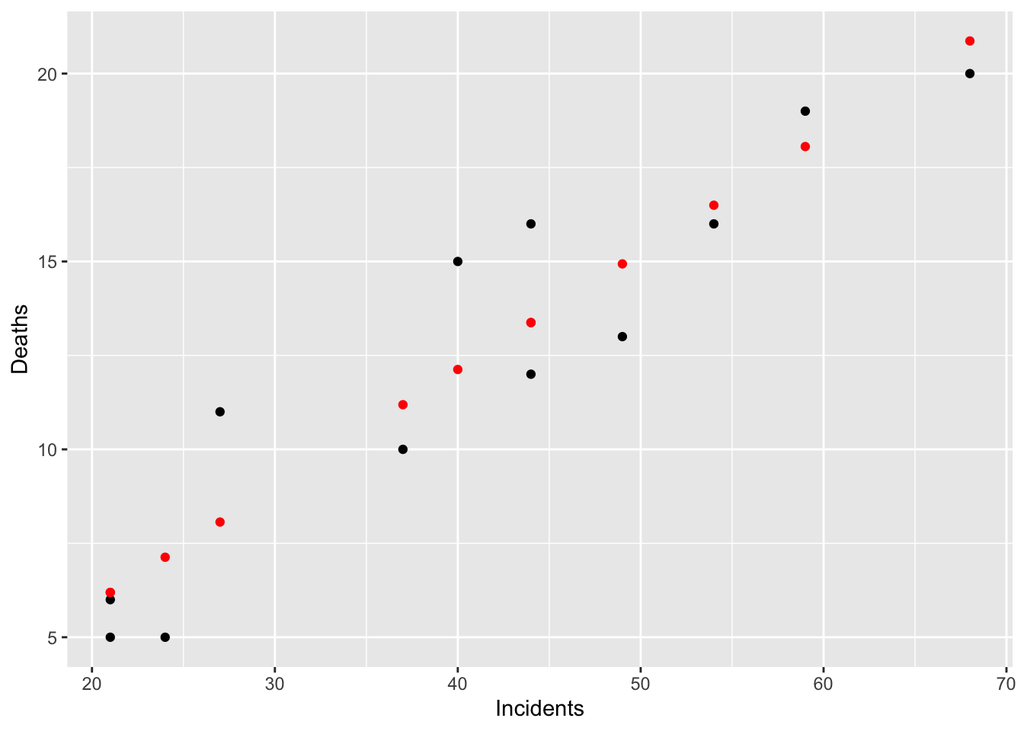

```r
nypd_csvData_Incidents_Pred <- nypd_csvData_Incidents_plot %>%
mutate(pred = predict(mod))

nypd_csvData_Incidents_Pred %>% ggplot() + geom_point(aes(x=Incidents, y=Deaths),color="black") + geom_point(aes(x=Incidents, y=pred),color = "red")
```

## BIAS AREAS

From the above model we can conclude that apart from a few outliers, our model somewhat predicts that as the incidents increases, the deaths also increases. Below are a few biases that could have affected our analysis :